# Bayesian estimation supercedes the t test

Jeffrey Chrabaszcz  
14 January 2014

### Work/time relationship

[figure not shown]

### Outline

1. Thinking about distributions
2. Exponential distribution
3. Hyperparameters
4. Beyond means
5. Priors for practical purposes
6. BEST

### Exponential distribution

The exponential distribution is only defined for \( x \ge 0 \).

\[ f(x) = \lambda e^{-\lambda x} \]

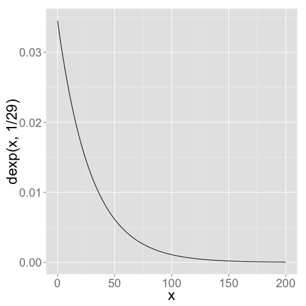

### Thinking about distributions

When using MCMC methods, you start to focus on different properties of distributions.

- Boundedness - single bound, double-bound, or unbound?
- Flexibility - beta can look like anything, uniform is nearly invariant
- Generation speed - generating draws from \( \mathcal{N}(0, 1) \) is trivial, Dirichlet and Cauchy draws are not

### Priors for practical purposes

Priors are included for two reasons:

1. Encode information relevant to a problem
2. Speed model convergence

When N becomes large, most things are approximated with a normal distribution. Before that, it often makes sense to pick a more appropriate likelihood distribution, especially when scores are bounded or priors are highly informed.

### Hyperparameters

We're going to abuse the word **prior** in a short few slides.

\[ y_i \sim \mathcal{N}(\beta_0 + \beta_k X_{ki}, \epsilon_i^2) \]

By default, we assume that our coefficients are drawn from a uniform without bounds.

\[ \beta_k \sim \mathcal{U}(-\infty, \infty) \]

\[ \beta_k \sim \mathcal{N}(0, \sigma_y^2) \]

### Beyond means

## Other parameters

What happens when we want to test the difference between the means of groups that have different variances? How about testing the difference between variances? The F test and Barlett's test both accomplish this, but are sensitive to violations of normality.

## Other distributions

What we don't want to assume a normal distribution and don't have a link function, or don't know the link function?

MCMC sampling offers a way to estimate distributions are parameters of any specified distribution.

### BEST

We can run a Bayesian t-test with BEST.

```r
library(BEST)
library(ISwR)
data(juul)
juul <- juul[complete.cases(juul$sex, juul$igf1),]
mod <- BESTmcmc(juul$igf1[juul$sex == 1], juul$igf1[juul$sex == 2], verbose = FALSE)
```

### BEST object

```
Classes 'BEST' and 'data.frame':    100002 obs. of  5 variables:
 $ mu1   : num  305 306 307 315 315 ...
 $ mu2   : num  378 374 372 377 372 ...
 $ nu    : num  53.5 59.4 31.1 57.9 63.1 ...
 $ sigma1: num  171 164 166 164 171 ...
 $ sigma2: num  164 154 159 160 155 ...
 - attr(*, "Rhat")= Named num  1 1 1 1 1
  ..- attr(*, "names")= chr  "mu[1]" "mu[2]" "nu" "sigma[1]" ...
 - attr(*, "n.eff")= Named num  58873 60603 23027 49505 51076
  ..- attr(*, "names")= chr  "mu[1]" "mu[2]" "nu" "sigma[1]" ...
 - attr(*, "data")=List of 2
  ..$ y1: num  101 97 106 111 79 43 64 90 141 42 ...
  ..$ y2: num  682 51 25 250 179 163 191 106 218 151 ...
```

### BEST output

```
             mean  median    mode HDI%   HDIlo   HDIup compVal %>compVal
mu1       308.525 308.553 308.869   95 292.962 323.994
mu2       366.175 366.166 365.680   95 351.840 380.476
muDiff    -57.650 -57.654 -57.938   95 -78.639 -36.760       0         0
sigma1    166.566 166.473 166.249   95 155.345 178.296
sigma2    164.593 164.500 164.365   95 154.160 175.264
sigmaDiff   1.973   1.953   2.206   95 -13.136  16.705       0        60
nu         59.775  51.813  37.567   95  15.040 125.132
log10nu     1.719   1.714   1.708   95   1.300   2.154
effSz      -0.348  -0.348  -0.346   95  -0.479  -0.224       0         0
```